# Tutorial 3

## Recap

Model:
$$\mathbb{E}(Y|X)=f(X)=\sum_{m=1}^M \beta_mh_m(X),$$
where $h_m(X)$ are basis functions.

Control of flexibility/complexity:

- restriction methods: i.e. additivity
- selection methods: i.e. CART, MARS and boosting
- regularization methods: i.e. ridge regression

Piecewise polynomials:

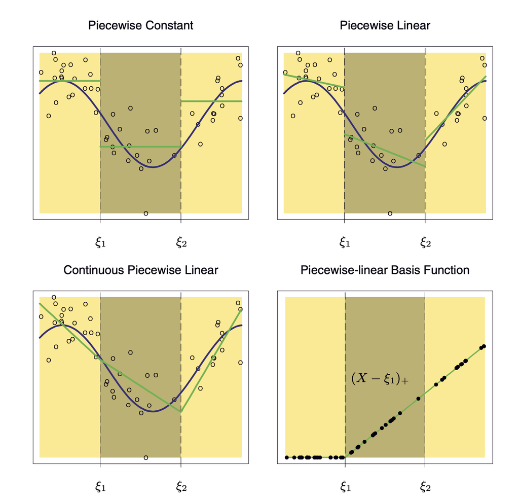

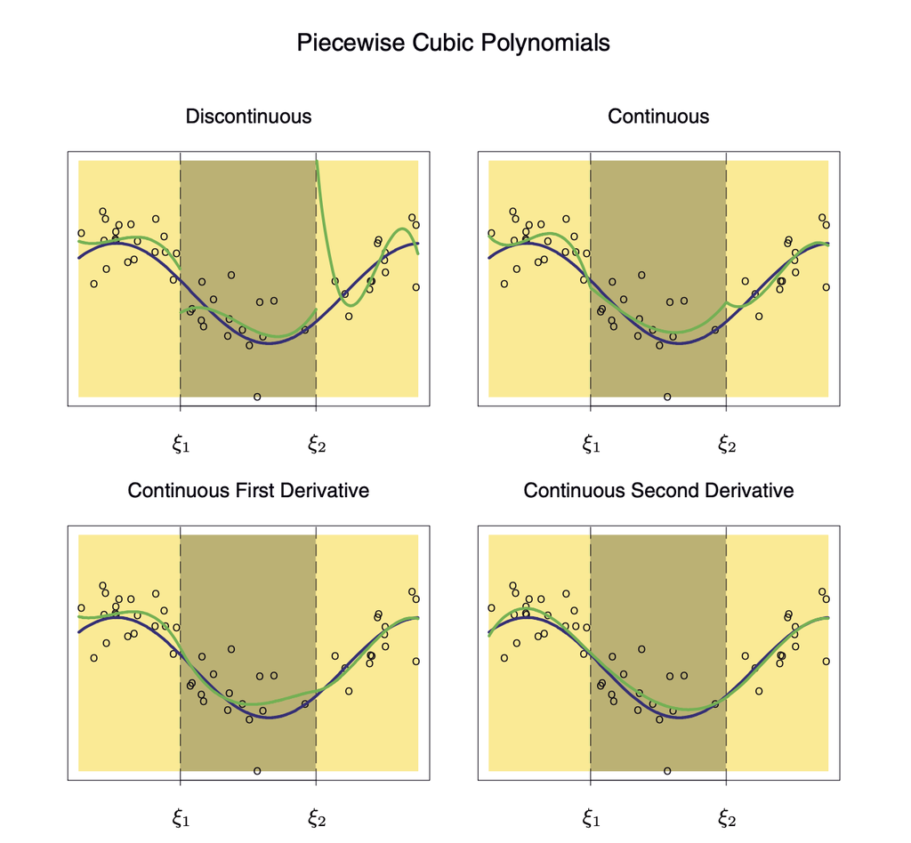

Smoothing spline:

- objective function
  $$\textrm{RSS}(f,\lambda)=\sum_{i=1}^n (y_i-f(x_i))^2+\lambda\int (f^{\prime\prime}(t))^2dt$$

## Smoothing Spline

Smoothing splines are a powerful approach for estimating functional relationships between a predictor X and a response Y. Smoothing splines can be fit using either the **smooth.spline** function (in the stats package) or the **ss** function (in the npreg package).

#### smooth.spline Function (stats package)

Syntax:

```
smooth.spline(x, y = NULL, w = NULL, df, spar = NULL, lambda = NULL,
                          cv = FALSE, all.knots = FALSE,
                          nknots = .nknots.smspl, keep.data = TRUE,
                          df.offset = 0, penalty = 1, control.spar = list(),
                          tol = 1e-6 * IQR(x), keep.stuff = FALSE)
```

#### ss Function (npreg Package)

Syntax:

```
ss(x, y = NULL, w = NULL, df, spar = NULL, lambda = NULL,
      method = c("GCV", "OCV", "GACV", "ACV", "REML", "ML", "AIC", "BIC"),
      m = 2L, periodic = FALSE, all.knots = FALSE, nknots = .nknots.smspl,
      knots = NULL, keep.data = TRUE, df.offset = 0, penalty = 1,
      control.spar = list(), tol = 1e-6 * IQR(x), bernoulli = TRUE)
```

#### Comparison of Approaches

Compared to the **smooth.spline** function, the **ss** function has

1. more smoothing parameter selection methods
2. more spline types (linear, cubic, quintic)
3. an option for periodicity constraints
4. an option for user-specified knot values
5. corresponding summary and plot methods

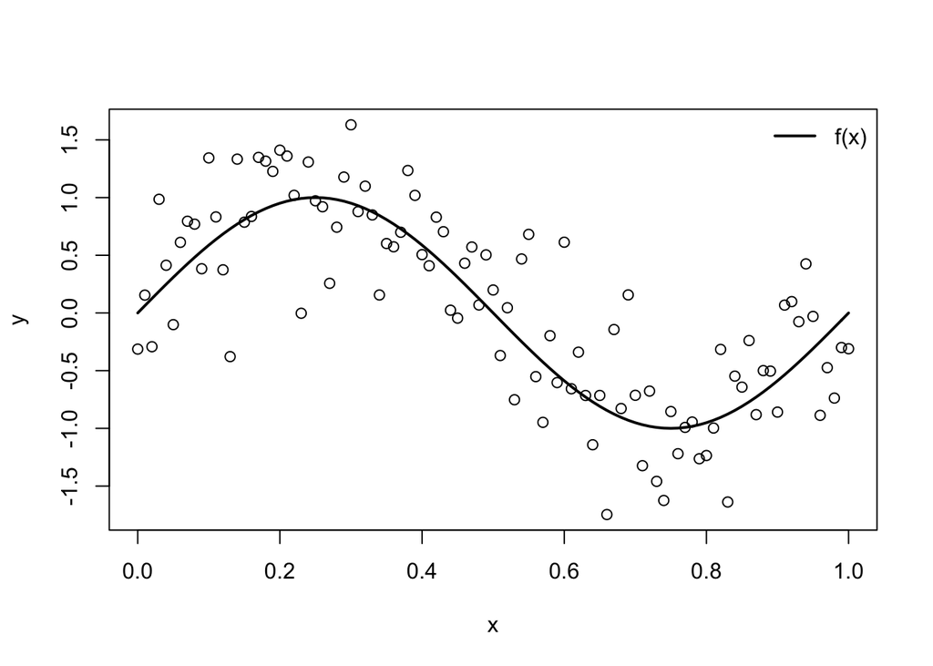

```r
# To see how these functions perform in practice, let’s look at a simulated example. Specifically, let’s simulate some data with a (periodic) functional relationship that has some noise.

# define function
n <- 101
x <- seq(0, 1, length.out = n)
fx <- sin(2 * pi * x)

# generate noisy data
set.seed(1)
y <- fx + rnorm(n, sd = 0.5)

# plot data and f(x)
plot(x, y)             # data
lines(x, fx, lwd = 2)  # f(x)
legend("topright", legend = "f(x)", lty = 1, lwd = 2, bty = "n")
```

```r
#Estimate function using smooth.spline and ss functions with 10 knots:
# load 'npreg' package
library(npreg)

# fit using ss
mod.ss <- ss(x, y, nknots = 10)
mod.ss
```

```
##
## Call:
## ss(x = x, y = y, nknots = 10)
##
## Smoothing Parameter  spar = 0.3294827   lambda = 1.431201e-05
## Equivalent Degrees of Freedom (Df) 6.432432
## Penalized Criterion (RSS) 19.31262
## Generalized Cross-Validation (GCV) 0.2181113
```

```r
# fit using smooth.spline
mod.smsp <- smooth.spline(x, y, nknots = 10)
mod.smsp
```

```
## Call:
## smooth.spline(x = x, y = y, nknots = 10)
##
## Smoothing Parameter  spar= 0.3108197  lambda= 0.001590704 (12 iterations)
## Equivalent Degrees of Freedom (Df): 6.348786
## Penalized Criterion (RSS): 19.36494
## GCV: 0.2183157
```

```r
#Note that the two functions produce objects that contain (nearly) identical results:
# compare returned objects
names(mod.ss)
```

```
##  [1] "x"        "y"        "w"        "yin"      "tol"      "data"
##  [7] "lev"      "cv.crit"  "pen.crit" "crit"     "df"       "spar"
## [13] "lambda"   "fit"      "call"     "sigma"    "logLik"   "aic"
## [19] "bic"      "penalty"  "method"
```

```r
names(mod.smsp)
```

```
##  [1] "x"          "y"          "w"          "yin"        "tol"
##  [6] "data"       "no.weights" "lev"        "cv.crit"    "pen.crit"
## [11] "crit"       "df"         "spar"       "ratio"      "lambda"
## [16] "iparms"     "auxM"       "fit"        "call"
```

```r
# rmse between solutions
sqrt(mean(( mod.ss$y - mod.smsp$y )^2))
```

```
## [1] 0.003092318
```

```r
# rmse between solutions and f(x)
sqrt(mean(( fx - mod.ss$y )^2))
```

```
## [1] 0.08363143
```

```r
sqrt(mean(( fx - mod.smsp$y )^2))
```

```
## [1] 0.08389557
```

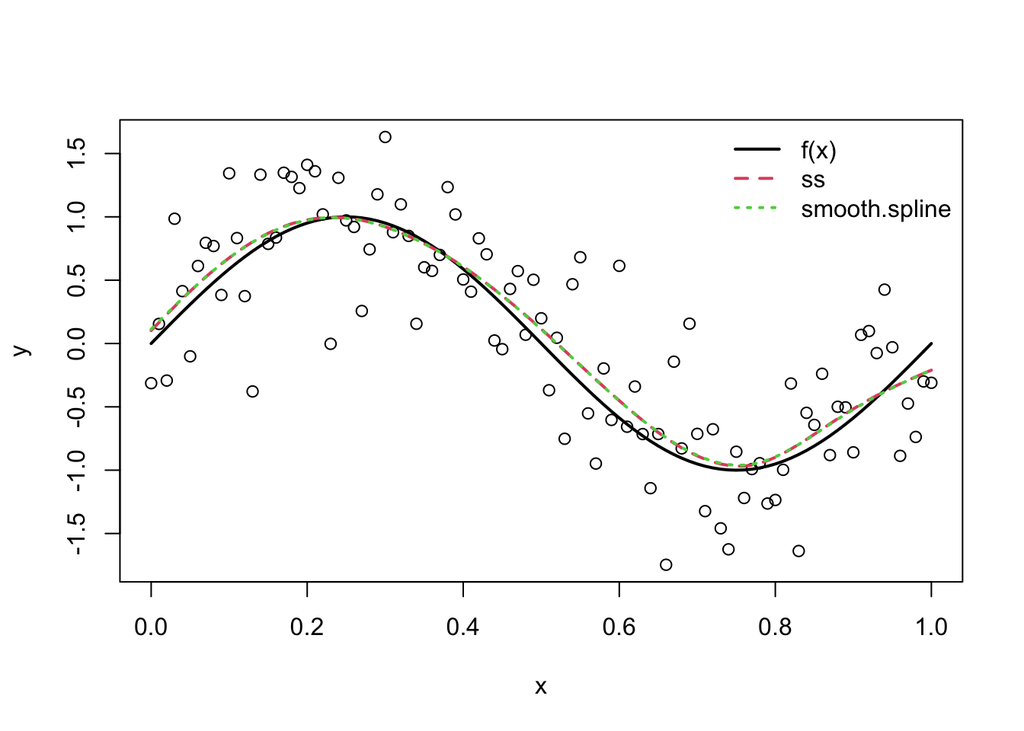

```r
# plot results
plot(x, y)
lines(x, fx, lwd = 2)
lines(x, mod.ss$y, lty = 2, col = 2, lwd = 2)
lines(x, mod.smsp$y, lty = 3, col = 3, lwd = 2)
legend("topright",
       legend = c("f(x)", "ss", "smooth.spline"),
       lty = 1:3, col = 1:3, lwd = 2, bty = "n")
```

Some extra features of the ss function include the “plot” and “summary” methods:

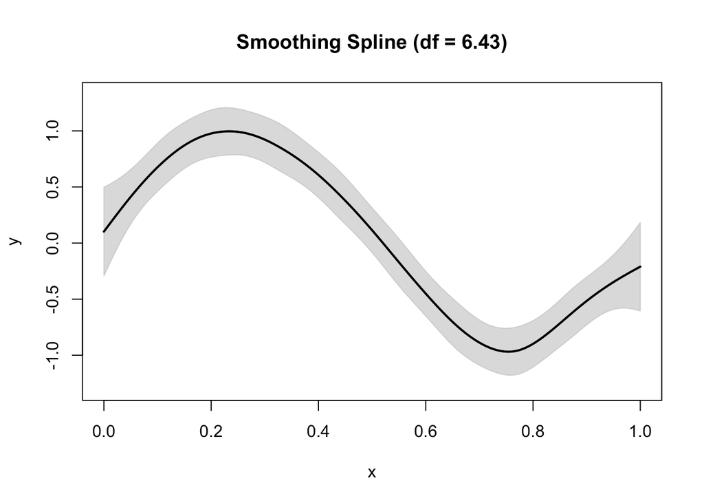

```r
# plot method
plot(mod.ss)
```

```r
# summary method
mod.sum <- summary(mod.ss)
mod.sum
```

```
##
## Call:
## ss(x = x, y = y, nknots = 10)
##
## Residuals:
##       Min        1Q    Median        3Q       Max
## -1.180772 -0.252248 -0.004237  0.295601  1.063916
##
## Approx. Signif. of Parametric Effects:
##             Estimate Std. Error t value Pr(>|t|)
## (Intercept)  0.05191    0.04499   1.154   0.2514
## x           -0.31243    0.28435  -1.099   0.2747
## ---
## Signif. codes:  0 '***' 0.001 '**' 0.01 '*' 0.05 '.' 0.1 ' ' 1
##
## Approx. Signif. of Nonparametric Effects:
##               Df Sum Sq Mean Sq F value   Pr(>F)
## s(x)       4.432  17.60  3.9712   19.45 2.09e-12 ***
## Residuals 94.568  19.31  0.2042
## ---
## Signif. codes:  0 '***' 0.001 '**' 0.01 '*' 0.05 '.' 0.1 ' ' 1
##
## Residual standard error: 0.4519 on 94.57 degrees of freedom
## Multiple R-squared:  0.7203,    Adjusted R-squared:  0.7038
## F-statistic: 43.7 on 5.432 and 94.57 DF,  p-value: <2e-16
```

Note that the summary function produces a printout that resembles what one would see from the **lm** or **glm** function

#### Smoothing Parameter Influence

$$f_\lambda=\min_f \textrm{RSS}(f,\lambda),$$
where
$$\textrm{RSS}(f,\lambda)=\sum_{i=1}^n (y_i-f(x_i))^2+\lambda\int (f^{\prime\prime}(t))^2dt$$

As $\lambda\to 0$ the penalty has less influence on the penalized least squares functional So, for very small values of $\lambda$, the function estimate $f_\lambda$ essentially minimizes the residual sum of squares.

As $\lambda\to\infty$ the penalty has more influence the penalized least squares functional So, for very large values of $\lambda$, the function estimate $f_\lambda$ is essentially constrained to have a zero penalty.

As $\lambda$ increases from $0$ to $\infty$, the function estimate $f_\lambda$ is forced to be smoother with respect to the penalty functional. The goal is to find the $\lambda$ that produces the “correct” degree of smoothness for the function estimate.

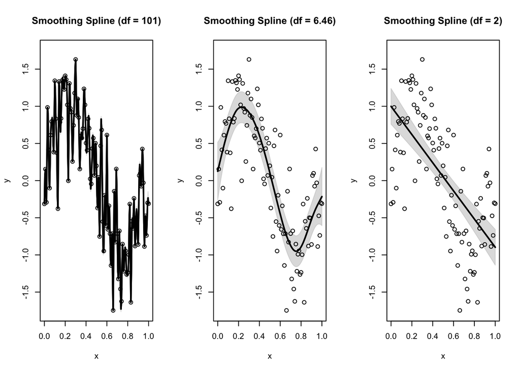

```r
# subplots (1 x 3)
par(mfrow = c(1,3))

# lambda = 1e-15 (df = n)
mod.ss0 <- ss(x, y, all.knots = TRUE, lambda = 1e-15)
plot(mod.ss0, ylim = c(-1.75, 1.75))
points(x, y)

# GCV selection
mod.ss <- ss(x, y, all.knots = TRUE)
plot(mod.ss, ylim = c(-1.75, 1.75))
points(x, y)

# lambda = 100 (df = m)
mod.ss10 <- ss(x, y, all.knots = TRUE, lambda = 100)
plot(mod.ss10, ylim = c(-1.75, 1.75))
points(x, y)
```

#### Penalty Order Influence

Setting $m=2$ produces a cubic smoothing spline, which penalizes the squared second derivative of the function. Cubic smoothing splines are the default in many software. Cubic smoothing splines estimate $f(\cdot)$ using piecewise cubic functions, which are connected at knots. The function estimates have two continuous derivatives at the knots, ensuring a smooth estimate of the function and its derivatives.

Setting $m=1$ results in a linear smoothing spline (a piecewise linear function), and setting $m=3$ produces a quintic smoothing spline (a piecewise quintic function).

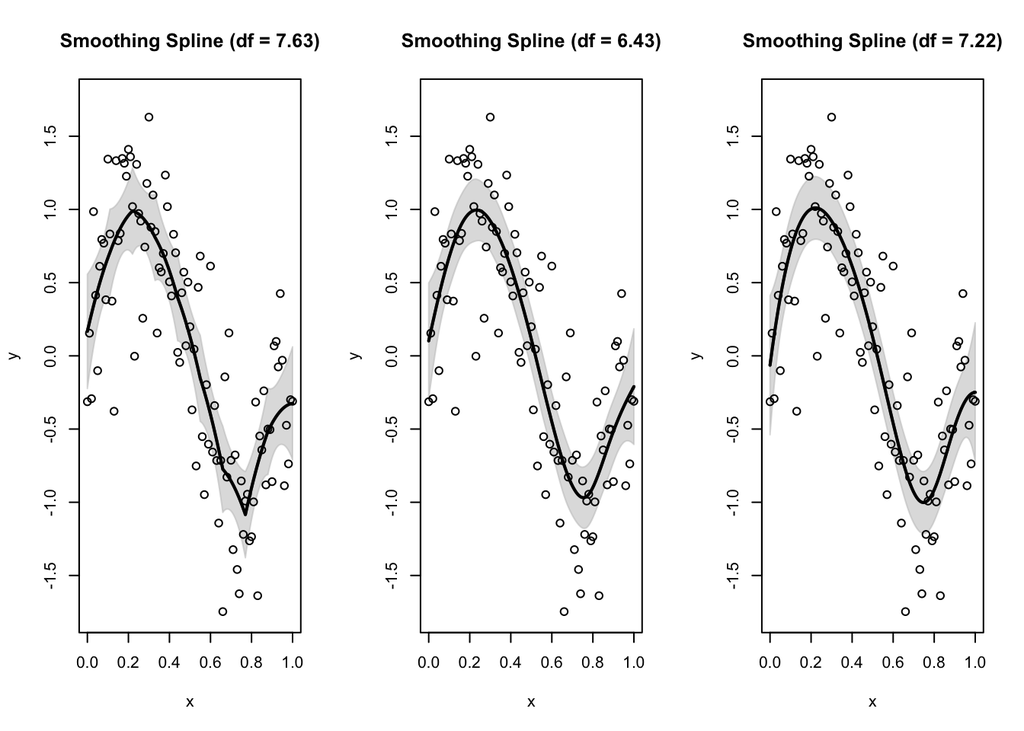

```r
mod.lin <- ss(x, y, nknots = 10, m = 1)
mod.cub <- ss(x, y, nknots = 10) ## m=2 by default
mod.qui <- ss(x, y, nknots = 10, m = 3)
par(mfrow = c(1,3))
plot(mod.lin, ylim = c(-1.75, 1.75))
points(x, y)
plot(mod.cub, ylim = c(-1.75, 1.75))
points(x, y)
plot(mod.qui, ylim = c(-1.75, 1.75))
points(x, y)
```

#### Example 1: Prestige from Income

```r
library(car)
#The Prestige dataset (from the car package) contains the prestige of n=102 Canadian occupations from 1971, as well as the average income of the occupation. We will use a smoothing spline to explore the relationship between prestige and income.

#First, let’s load the data and visualize the relationship between income (X) and prestige (Y).
data(Prestige)
head(Prestige)
```

|  | education | income | women | prestige | census | type |
| --- | --- | --- | --- | --- | --- | --- |
| gov.administrators | 13.11 | 12351 | 11.16 | 68.8 | 1113 | prof |
| general.managers | 12.26 | 25879 | 4.02 | 69.1 | 1130 | prof |
| accountants | 12.77 | 9271 | 15.70 | 63.4 | 1171 | prof |
| purchasing.officers | 11.42 | 8865 | 9.11 | 56.8 | 1175 | prof |
| chemists | 14.62 | 8403 | 11.68 | 73.5 | 2111 | prof |
| physicists | 15.64 | 11030 | 5.13 | 77.6 | 2113 | prof |

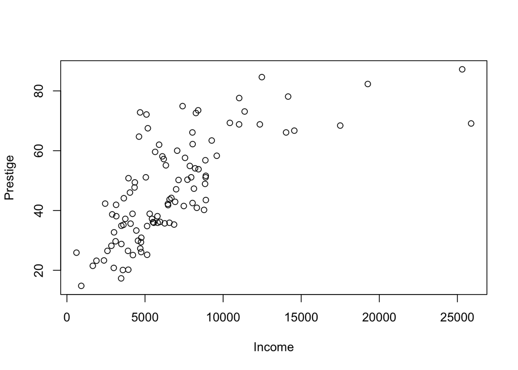

```r
# plot data
plot(Prestige$income, Prestige$prestige,
     xlab = "Income", ylab = "Prestige")
```

```r
# fit model
mod.ss <- with(Prestige, ss(income, prestige))
mod.ss
```

```
##
## Call:
## ss(x = income, y = prestige)
##
## Smoothing Parameter  spar = 0.4923283   lambda = 0.0002148891
## Equivalent Degrees of Freedom (Df) 3.467512
## Penalized Criterion (RSS) 12118.05
## Generalized Cross-Validation (GCV) 127.3134
```

```r
# summarize fit
summary(mod.ss)
```

```
##
## Call:
## ss(x = income, y = prestige)
##
## Residuals:
##     Min      1Q  Median      3Q     Max
## -16.991  -7.727  -2.453   7.586  33.006
##
## Approx. Signif. of Parametric Effects:
##             Estimate Std. Error t value  Pr(>|t|)
## (Intercept)    63.08      2.228  28.310 0.000e+00 ***
## x              61.01      8.035   7.593 1.807e-11 ***
## ---
## Signif. codes:  0 '***' 0.001 '**' 0.01 '*' 0.05 '.' 0.1 ' ' 1
##
## Approx. Signif. of Nonparametric Effects:
##               Df Sum Sq Mean Sq F value    Pr(>F)
## s(x)       1.468   2125    1448   11.78 0.0001596 ***
## Residuals 98.532  12118     123
## ---
## Signif. codes:  0 '***' 0.001 '**' 0.01 '*' 0.05 '.' 0.1 ' ' 1
##
## Residual standard error: 11.09 on 98.53 degrees of freedom
## Multiple R-squared:  0.5949,    Adjusted R-squared:  0.5845
## F-statistic: 57.35 on 2.468 and 98.53 DF,  p-value: <2e-16
```

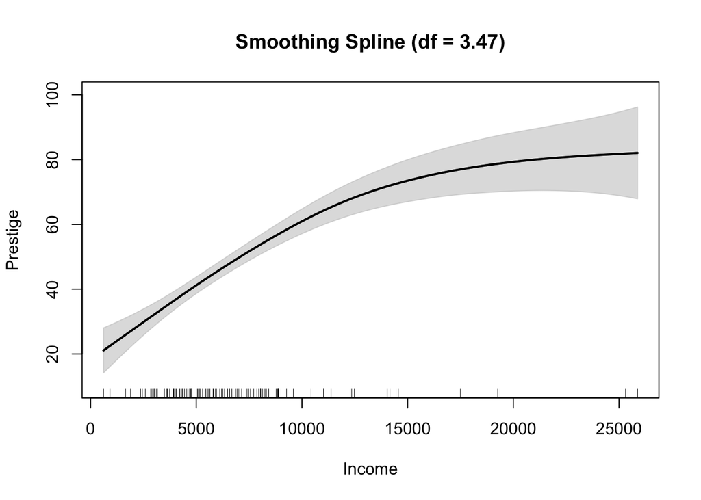

```r
# plot fit
# The gray shaded area denotes a 95% Bayesian “confidence interval” for the unknown function.
plot(mod.ss, xlab = "Income", ylab = "Prestige")
rug(Prestige$income)  # add rug to plot
```

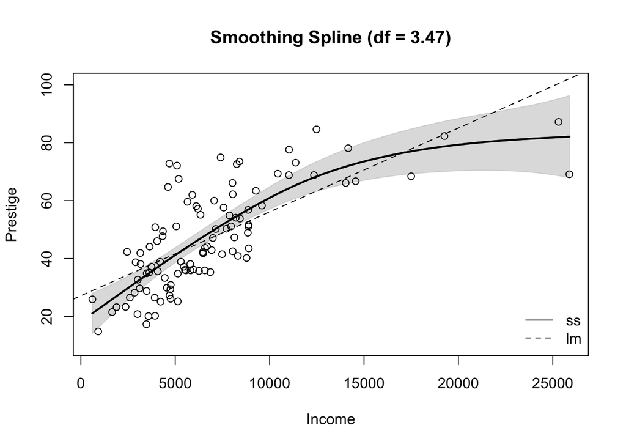

```r
#Compare to lm fit:

# plot ss fit
plot(mod.ss, xlab = "Income", ylab = "Prestige")

# add lm fit
abline(coef(lm(prestige ~ income, data = Prestige)), lty = 2)

# add data and legend
with(Prestige, points(income, prestige))
legend("bottomright", legend = c("ss", "lm"), lty = 1:2, bty = "n")
```

#### Example 2: Motorcycle Accident

```r
# Example 2

#The mcycle dataset (from the MASS package) contains n=133 pairs of time points (in ms) and observed head accelerations (in g) that were recorded in a simulated motorcycle accident. We will use a smoothing spline to explore the relationship between time and acceleration.

#First, let’s load the data and visualize the relationship between time (X) and acceleration (Y).

# load data
library(MASS)
data(mcycle)
head(mcycle)
```

|  | times | accel |
| --- | --- | --- |
| 1 | 2.4 | 0.0 |
| 2 | 2.6 | -1.3 |
| 3 | 3.2 | -2.7 |
| 4 | 3.6 | 0.0 |
| 5 | 4.0 | -2.7 |
| 6 | 6.2 | -2.7 |

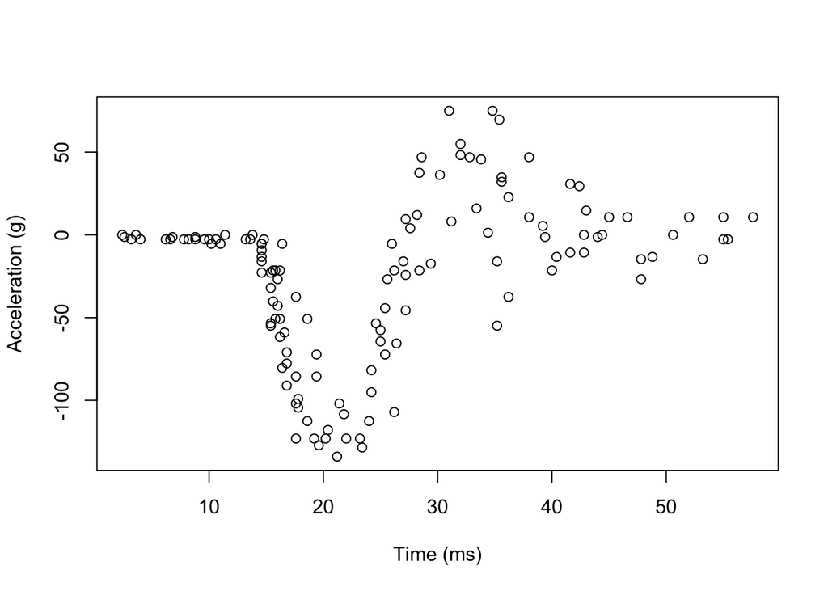

```r
# plot data
plot(mcycle$times, mcycle$accel,
     xlab = "Time (ms)", ylab = "Acceleration (g)")
```

```r
# fit model
mod.ss <- with(mcycle, ss(times, accel))
mod.ss
```

```
##
## Call:
## ss(x = times, y = accel)
##
## Smoothing Parameter  spar = 0.1585867   lambda = 8.337281e-07
## Equivalent Degrees of Freedom (Df) 12.20781
## Penalized Criterion (RSS) 62034.66
## Generalized Cross-Validation (GCV) 565.4684
```

```r
# summarize fit
summary(mod.ss)
```

```
##
## Call:
## ss(x = times, y = accel)
##
## Residuals:
##      Min       1Q   Median       3Q      Max
## -76.7951 -12.5654  -0.8346  12.5823  50.5576
##
## Approx. Signif. of Parametric Effects:
##             Estimate Std. Error t value  Pr(>|t|)
## (Intercept)  -14.234      2.313  -6.154 1.018e-08 ***
## x              9.549     21.603   0.442 6.593e-01
## ---
## Signif. codes:  0 '***' 0.001 '**' 0.01 '*' 0.05 '.' 0.1 ' ' 1
##
## Approx. Signif. of Nonparametric Effects:
##               Df Sum Sq Mean Sq F value Pr(>F)
## s(x)       10.21 210130 20585.3   40.08      0 ***
## Residuals 120.79  62035   513.6
## ---
## Signif. codes:  0 '***' 0.001 '**' 0.01 '*' 0.05 '.' 0.1 ' ' 1
##
## Residual standard error: 22.66 on 120.8 degrees of freedom
## Multiple R-squared:  0.7999,    Adjusted R-squared:  0.7801
## F-statistic: 41.21 on 11.21 and 120.8 DF,  p-value: <2e-16
```

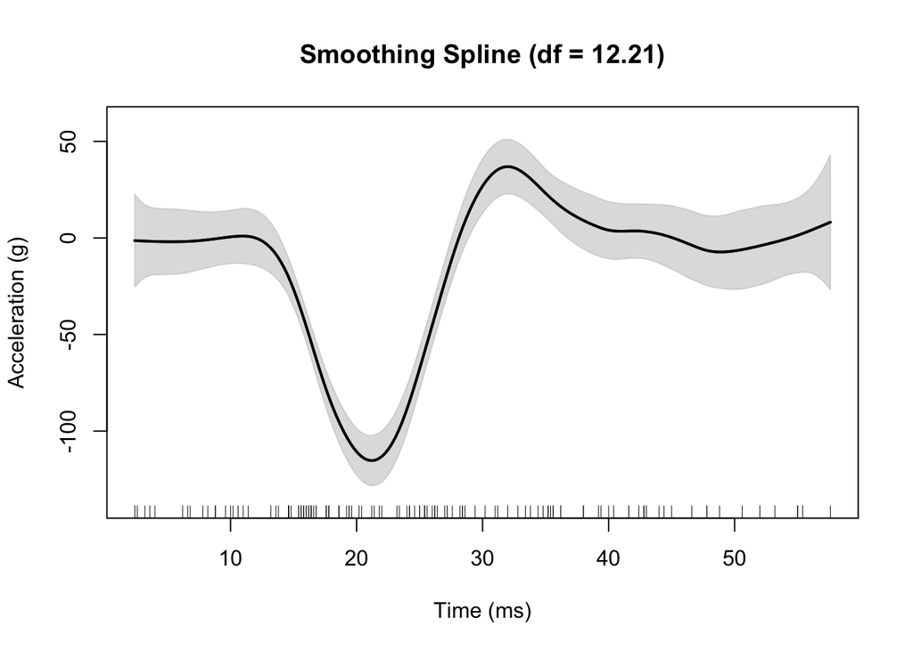

```r
# plot fit
# The gray shaded area denotes a 95% Bayesian “confidence interval” for the unknown function.
plot(mod.ss, xlab = "Time (ms)", ylab = "Acceleration (g)")
rug(mcycle$times)  # add rug to plot
```